# Week 2: Bonus Material

Helene Wagner

2024-01-09

## 1. Overview

This bonus vignette uses the packages `sf`, `terra`, and `tmap`, yet it can only scratch the surface. For a thorough introduction to geocomputation with R, see this excellent Gitbook: https://geocompr.robinlovelace.net/index.html.

### a) Goals

This bonus material expands the Worked Example to show:

- How to import and export ESRI shapefiles.
- Compatibility with packages `sp` and `raster`
- How to create static and interactive maps with `tmap`.
- How to plot a categorical raster with a predefined color scheme.

Try modifying the code to import your own data!

### b) Required R packages

```r
library(LandGenCourse)
library(sf)
library(GeNetIt)
library(terra)
library(tmap)
library(dplyr)
library(tibble)
library(here)
```

## 2. Import and export ESRI shapefiles

ESRI shapefiles are a widely used data format for sharing geospatial vector data. With the package sf, they are easy to import and export. Here’ we will export Sites.sf to a shapefile and then import it again.

### a) Export ‘sf’ object to shapefile

The following code may produce a warning that column names were abbreviated. It writes the component files for the ESRI shapefile into the pre-existing folder `output` (the first line will create it if does not exist yet). Remember to remove the hashtags ‘#’ to un-comment the code before running it.

The argument `delete_dsn` specifies whether any existing file with the same name should be deleted first (i.e., overwritten).

```r
data(ralu.site)
#if(!dir.exists(here("output"))) dir.create(here("output"))
#dir.create(here("output/Sites"))
#st_write(ralu.site, here("output/Sites/Sites.shp"), delete_dsn = TRUE)
```

Navigate to the `Sites` folder in the `output` folder (Files tab). You should now see four component files of the shapefile. These four files are required parts of the shapefile, always keep (or share) them together! Some shapefiles will have additional, optional component files.

- Sites.dbf
- Sites.prj
- Sites.shp
- Sites.shx

### b) Import shapefile to ‘sf’ object

Importing a shapefile is very easy with the function `st_read` from the `sf` package. While you only need to provide the path to the `.shp` file, the other files listed above must be in the same folder.

```r
#Sites.sf_a <- st_read(here("output/Sites/Sites.shp"))
#Sites.sf_a
```

## 3. Compatibility with `sp` and `raster` objects

The packages sf and terra recently replaced the older packages sp and raster. You may still encounter code that requires objects from these packages. Here we show how to convert between sf and sp, and between terra and raster. The conversion is easy, though please note that sp objects are S4 objects.

### a) Converting between `sf` and `sp`

It is easy to convert an `sf` object into a `Spatial` object of package `sp`, using the function `as_Spatial` of the `sf` package. For point data, the resulting class will be a `SpatialPointsDataFrame`.

```r
data(ralu.site)
Sites.sp <- sf::as_Spatial(ralu.site)
Sites.sp
```

```
## class       : SpatialPointsDataFrame
## features    : 31
## extent      : 686908.5, 690890.1, 4994089, 5004435  (xmin, xmax, ymin, ymax)
## crs         : +proj=utm +zone=11 +datum=NAD83 +units=m +no_defs
## variables   : 17
## names       :     SiteName,    Drainage,    Basin, Substrate,                                          NWI,  AREA_m2, PERI_m, Depth_m, TDS, FISH,  ACB,   AUC,  AUCV,  AUCC, AUF, ...
## min values  : AirplaneLake,  ClearCreek, Birdbill,    Cobble,                                   Lacustrine,        0,      0,       0,   0,    0,    0,     0,     0,     0,   0, ...
## max values  :  WelcomeLake, WilsonCreek,   TipTop,      Silt, Riverine_UpperPerennial_UnconsolidatedBottom, 353898.1, 4312.9,    24.3,  20,    1, 0.11, 0.817, 0.463, 0.817,   1, ...
```

We can convert the `Spatial` object back to an `sf` object with the function `st_as_sf` of the `sf` package:

```r
Sites.sf_b <- sf::st_as_sf(Sites.sp)
Sites.sf_b
```

```
## Simple feature collection with 31 features and 17 fields
## Geometry type: POINT
## Dimension:     XY
## Bounding box:  xmin: 686908.5 ymin: 4994089 xmax: 690890.1 ymax: 5004435
## Projected CRS: +proj=utm +zone=11 +datum=NAD83 +units=m +no_defs
## First 10 features:
##          SiteName        Drainage      Basin Substrate
## 1    AirplaneLake ShipIslandCreek Sheepeater      Silt
## 2  BachelorMeadow     WilsonCreek    Skyhigh      Silt
## 3  BarkingFoxLake  WaterfallCreek    Terrace      Silt
## 4    BirdbillLake      ClearCreek   Birdbill      Sand
## 5         BobLake     WilsonCreek     Harbor      Silt
## 6       CacheLake     WilsonCreek    Skyhigh      Silt
## 7         DoeLake     WilsonCreek    Skyhigh      Silt
## 8    EggWhiteLake     WilsonCreek    Skyhigh      Silt
```

[output cut: 24 more lines]

### b) Converting between `terra` and `raster`

To convert a `SpatRaster` (`terra`) with multiple layers into `RasterStack` of the package `raster`, we use the function `stack` of the `raster` package:

```r
RasterMaps <- rast(system.file("extdata/covariates.tif", package="GeNetIt"))

RasterMaps.r <- raster::stack(RasterMaps)
RasterMaps.r
```

```
## class      : RasterStack
## dimensions : 426, 358, 152508, 6  (nrow, ncol, ncell, nlayers)
## resolution : 30, 30  (x, y)
## extent     : 683282.5, 694022.5, 4992833, 5005613  (xmin, xmax, ymin, ymax)
## crs        : +proj=utm +zone=11 +datum=NAD83 +units=m +no_defs
## names      :          cti,        err27,          ffp,          gsp,          hli,         nlcd
## min values : 8.429851e-01, 3.906551e-02, 0.000000e+00, 2.270000e+02, 1.014000e+03, 1.100000e+01
## max values :   23.7147598,    0.7637643,   51.0000000,  338.0696716, 9263.0000000,   95.0000000
```

To convert a single layer into a `RasterLayer` of the package `raster`, we would use the function `raster`:

```r
nlcd.r <- raster::raster(RasterMaps$nlcd)
nlcd.r
```

```
## class      : RasterLayer
## band       : 6  (of  6  bands)
## dimensions : 426, 358, 152508  (nrow, ncol, ncell)
## resolution : 30, 30  (x, y)
## extent     : 683282.5, 694022.5, 4992833, 5005613  (xmin, xmax, ymin, ymax)
## crs        : +proj=utm +zone=11 +datum=NAD83 +units=m +no_defs
## source     : covariates.tif
## names      : nlcd
## values     : 11, 95  (min, max)
```

To convert from a `RasterLayer` (package `raster`) to a SpatRaster (package `terra`), we use the function `rast` of the `terra` package:

```r
nlcd <- terra::rast(nlcd.r)
nlcd
```

```
## class       : SpatRaster
## dimensions  : 426, 358, 1  (nrow, ncol, nlyr)
## resolution  : 30, 30  (x, y)
## extent      : 683282.5, 694022.5, 4992833, 5005613  (xmin, xmax, ymin, ymax)
## coord. ref. : +proj=utm +zone=11 +datum=NAD83 +units=m +no_defs
## source      : covariates.tif
## name        : nlcd
## min value   :   11
## max value   :   95
```

We can use the same function to convert from a `RasterStack` (package `raster`) to a SpatRaster with multiple layers (package `terra`):

```r
RasterMaps_b <- terra::rast(RasterMaps.r)
RasterMaps_b
```

```
## class       : SpatRaster
## dimensions  : 426, 358, 6  (nrow, ncol, nlyr)
## resolution  : 30, 30  (x, y)
## extent      : 683282.5, 694022.5, 4992833, 5005613  (xmin, xmax, ymin, ymax)
## coord. ref. : +proj=utm +zone=11 +datum=NAD83 +units=m +no_defs
## source      : covariates.tif
## names       :        cti,      err27, ffp,      gsp,  hli, nlcd
## min values  :  0.8429851, 0.03906551,   0, 227.0000, 1014,   11
## max values  : 23.7147598, 0.76376426,  51, 338.0697, 9263,   95
```

## 4. Plotting spatial data with `tmap`

### a) Plot geometry

The package `sf` makes a clear distinction between the geometry information (spatial coordinates: where in space) and attribute information (what’s at these locations). Hence, when using the function `plot` with `sf` objects, we need to decide what we want to plot: geometry or attributes?

To plot the geometry, we use function `st_geometry` to extract the geometry information from the `sf` object:

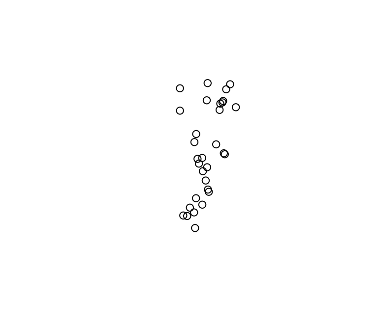

```r
data(ralu.site)
Sites.sf_c <- ralu.site
plot(st_geometry(Sites.sf_c))
```

### b) Plot attributes in space

If we don’t extract the geometry, then R will assume that we want to plot attribute data. The default is to plot the first ten attributes.

Here we set the point character `pch` to a filled circle, which is symbol #16. With `cex=2`, we define the symbol size.

For an overview of ‘pch’ symbol numbers, and colors, check: http://vis.supstat.com/2013/04/plotting-symbols-and-color-palettes/

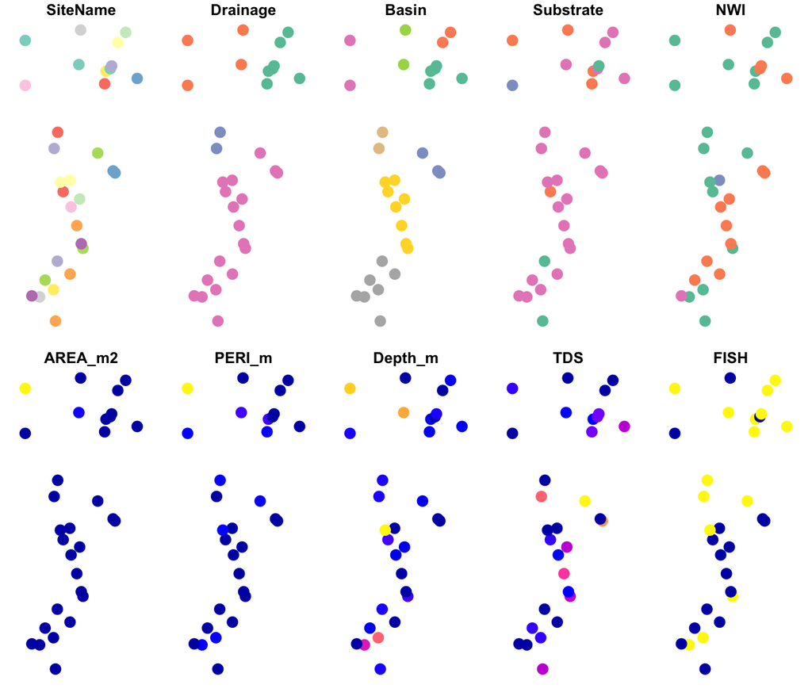

```r
par(mar=c(2,2,2,2))
plot(Sites.sf_c, pch=16, cex=2)
```

This is pretty cool! Let’s have a closer look at two of the variables.

Note: To learn about options for the `plot` function for `sf` objects, access the help file by typing `?plot` and select ‘Plot sf object’.

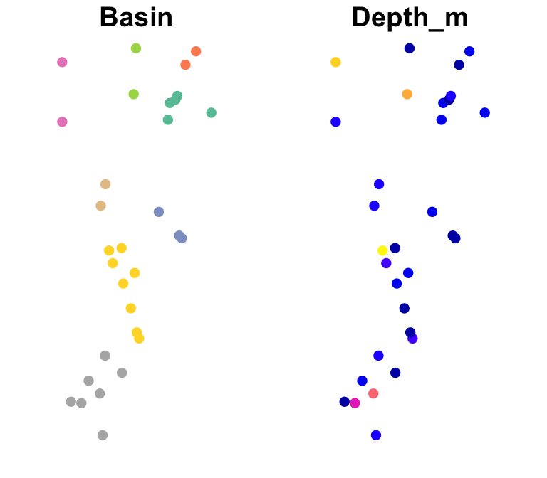

```r
plot(Sites.sf_c[,c("Basin", "Depth_m")], pch=16)
```

### c) Create a static bubble plot with ‘tmap’

The `tmap` package (for plotting thematic maps) is a great tool for plotting maps. It is based on the grammar of graphics concepts, which take a bit of getting used to. Most importantly, we need the following parts:

- `tmap_mode("plot")`: to plot a static map (default)
- `tm_shape`: this function defines the data to be used.
- `tm_sf`: this function defines what information should be plotted and how.

Note: for the second part, there are many other functions for various types of data.

If we use `tm_sf` without arguments (i.e., with the default settings), we get a plot of the geometry:

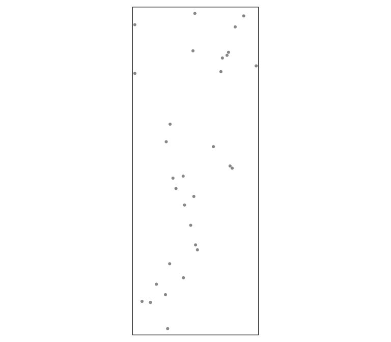

```r
tmap_mode("plot")
tm_shape(Sites.sf_c) + tm_sf()
```

We can indicate an attribute to plot it. Also, there is a special function `tm_bubbles` for bubble plots. Here we define the bubble size by wetland depth and bubble color by basin. In addition, we specify that the legend should be placed outside of the plot, on the right.

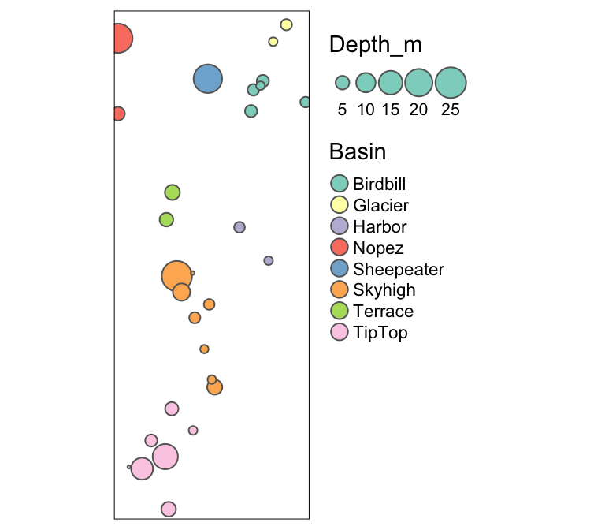

```r
tmap_mode("plot")
tm_shape(Sites.sf_c) + tm_bubbles(size="Depth_m", col="Basin") +
  tm_layout(legend.outside=TRUE, legend.outside.position="right")
```

Let’s make the boundary box (map extent) a little larger so that the symbols are not cut off. First we extract the boundary box of `Sites.sf_c` and save it as `Bbox`.

```r
Bbox = st_bbox(Sites.sf_c)
Bbox
```

```
##      xmin      ymin      xmax      ymax
##  686908.5 4994089.3  690890.1 5004435.0
```

Then we define the range along x and y coordinates (`delta.x`, `delta.y`), set a zoom factor (`Zoom`) and add that fraction of the range on each side. Unfortunately, there is no dedicated function for this so we do this manually:

```r
delta.x <- Bbox[3] - Bbox[1]
delta.y <- Bbox[4] - Bbox[2]
Zoom <- 0.1
Bbox2 <- Bbox + c(-delta.x, -delta.y, delta.x, delta.y) * Zoom
Bbox2
```

```
##      xmin      ymin      xmax      ymax
##  686510.4 4993054.7  691288.2 5005469.6
```

Now we add the boundary box information as an argument `bbox` in function `tm_shape`.

Note that we write the figure into an object, `Map1`, then plot the `Map1`. This will help e.g. with exporting the map, or we can later add more layers to this map object with `+`.

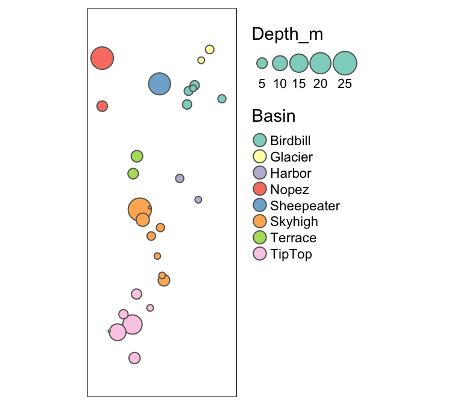

```r
tmap_mode("plot")
Map1 <- tm_shape(Sites.sf_c, bbox=Bbox2) +
  tm_bubbles(size="Depth_m", col="Basin") +
  tm_layout(legend.outside=TRUE, legend.outside.position="right")
Map1
```

### d) Create an interactive bubble plot with ‘tmap’

Creating an interactive map with a basemap from the internet is not difficult. Un-comment the code below by removing the hashtag (#) and run it. Go ahead and play with the interactive map!

```r
#tmap_mode("view")
#tm_shape(Sites.sf_c) + tm_bubbles(size="Depth_m", col="Basin")
```

By default, R will include an interactive menu to toggle between “Esri.WorldGrayCanvas”, “OpenStreetMap”, and “Esri.WorldTopoMap”. We can add more base maps to this selection by providing a list of servers with the function `tm_basemap`. The first one listed will be shown by default.

```r
#tm_shape(Sites.sf_c) + tm_bubbles(size="Depth_m", col="Basin") +
#tm_basemap(server = c("Esri.WorldTopoMap", "Esri.WorldGrayCanvas",
#                        "OpenStreetMap", "OpenTopoMap", "Esri.WorldImagery"))
```

Let’s make a few more changes:

- We change the symbolization to fixed-size, filled circles with a black border, and plot them on top of filled circles that indicate the basin. Note that although both attributes are in the same dataset `Sites.sf_c`, we need to include a data statement for each attribute we add to the map (i.e., map layer), using `tm_shape(Sites.sf)`.
- We include the argument `bbox=Bbox2` for at least one of the map layers. This is not needed for the interactive map but will look better when exporting it as a static map.

Un-comment the code below by removing the hashtag (#) and run it. Go ahead and toggle between the base maps in the map below! Different base maps are suitable for different situations (data type, symbol type, size of study area) and purposes.

```r
#tmap_mode("view")

#Map2 <- tm_shape(Sites.sf_c, bbox=Bbox2) +  tm_sf("Basin", size=2, border.col="black") +
#  tm_shape(Sites.sf_c) + tm_sf(size=0.8, col="Depth_m",
#                             palette = "Blues", border.col="black") +
#  tm_basemap(server = c("Esri.WorldTopoMap", "Esri.WorldGrayCanvas",
#                        "OpenStreetMap", "OpenTopoMap", "Esri.WorldImagery"))
#Map2
```

### e) Export maps

Save the map to folder `output`:

- Remember to un-comment the code by removing the hashtags (#).
- Interactive map saved to `html` file. This includes all the features of the interactive map `Map2`.
- Static map saved to `png` file, with height = 7 inches. This drops the base map and retains only the symbolized data.

Go ahead and check out the two files!

```r
#if(!dir.exists(here("output"))) dir.create(here("output"))
#tmap_save(Map1, here::here("output/StaticMap.png"), height=7)
#tmap_save(Map2, here::here("output/InteractiveMap.html"))
```

Navigate to the folder `output` (Files tab) and check out the saved maps! For the dynamic map (Map2), select “open in a web browser”. You can share this file with others, who can open it in their browser and interact with the map without access to R or your data!

## 5. Plot a categorical map with predefined color scheme

### a) Define the raster attribute table

Now to a more tricky topic. Recall that the last raster layer in the Worked Example, `nlcd`, contains categorical land cover data that are coded numerically. The `terra` package actually misinterpreted them as numeric data.

Let’s extract the categorical raster layer into a new object ‘NLCD’. We can use `as.factor` to tell R that this is a categorical raster layer.

Here, we save the (numerical) raster layer `nlcd` as categorical raster (factor) `NLCD`.

```r
RasterMaps <- rast(system.file("extdata/covariates.tif", package="GeNetIt"))
NLCD <- terra::as.factor(RasterMaps$nlcd)
```

What values occur in the raster? These are codes for cover types.

Here is a description of the cover types: https://www.mrlc.gov/data/legends/national-land-cover-database-2019-nlcd2019-legend

```r
levels(NLCD)[[1]]
```

```
##   ID nlcd
## 1 11   11
## 2 12   12
## 3 31   31
## 4 42   42
## 5 52   52
## 6 71   71
## 7 90   90
## 8 95   95
```

We will import a table with predefined colors (using hex color code) from the file `Colortable_LULC.csv` that is included with `LandGenCourse`.

This list has more entries (e.g., 21-24) than we need, because not all US land cover classes occur in the study area.

Check in the table below that the colors and cover types are stored as ‘character’. (Luckily, since R 4.0, this is the new default for function `read.csv`). If they were coded as factors that could lead to errors later on.

```r
ColTab <- read.csv(system.file("extdata", "Colortable_LULC.csv",
                            package = "LandGenCourse"), header=TRUE)
ColTab
```

```
##    value   color                    attribute
## 1     11 #456DA8                   Open Water
## 2     12 #E6EEF9           Perennial Ice/Snow
## 3     21 #E1CBCD        Developed, Open Space
## 4     22 #DC9786     Developed, Low Intensity
## 5     23 #F40100  Developed, Medium Intensity
## 6     24 #B00206    Developed, High Intensity
## 7     31 #B2AEA3 Barren Land (Rock/Sand/Clay)
## 8     41 #6BA95C             Deciduous Forest
## 9     42 #16692E             Evergreen Forest
## 10    43 #B9CA8F                 Mixed Forest
## 11    51 #AD9439                  Dwarf Scrub
## 12    52 #D5B883                  Shrub/Scrub
## 13    71 #EDEFCA         Grassland/Herbaceous
## 14    72 #D3D27C             Sedge/Herbaceous
## 15    73 #A5CD53                      Lichens
## 16    74 #88B8A1                         Moss
## 17    81 #DED73E                  Pasture/Hay
## 18    82 #AD722C             Cultivated Crops
## 19    90 #BED8F6               Woody Wetlands
## 20    95 #6EA5C4 Emergent Herbaceous Wetlands
```

We join this list with the list of factor levels of `NLCD` to create a raster attribute table (RAT). An RAT is a table that contains attributes for each distinct value in a raster.

- Use function `left_join` to extract the corresponding row from `ColTab` for each row in `Levels(NLCD)`
- Indicate which columns should be used to match the rows: `by=c("ID"="value")`. Note that `ID` is of type `numeric` whereas `nlcd` is `character`. As `value` is numeric, we match it with `ID`.
- Copy the values from variable `attribute` to variable `nlcd`
- Select the variables that we will need.

```r
RAT <- dplyr::left_join(levels(NLCD)[[1]], ColTab, by=c("ID"="value")) %>%
  mutate(nlcd=attribute) %>%
  dplyr::select(ID, nlcd, color)
```

We replace the list of levels by the RAT:

```r
levels(NLCD) <- RAT
NLCD
```

```
## class       : SpatRaster
## dimensions  : 426, 358, 1  (nrow, ncol, nlyr)
## resolution  : 30, 30  (x, y)
## extent      : 683282.5, 694022.5, 4992833, 5005613  (xmin, xmax, ymin, ymax)
## coord. ref. : NAD83 / UTM zone 11N (EPSG:26911)
## source      : covariates.tif
## categories  : nlcd, color
## name        :                         nlcd
## min value   :                   Open Water
## max value   : Emergent Herbaceous Wetlands
```

### b) Plot the map with `terra::plot`

Now we can plot the map with the predefined color palette, using the `plot` function for `SpatRaster` objects:

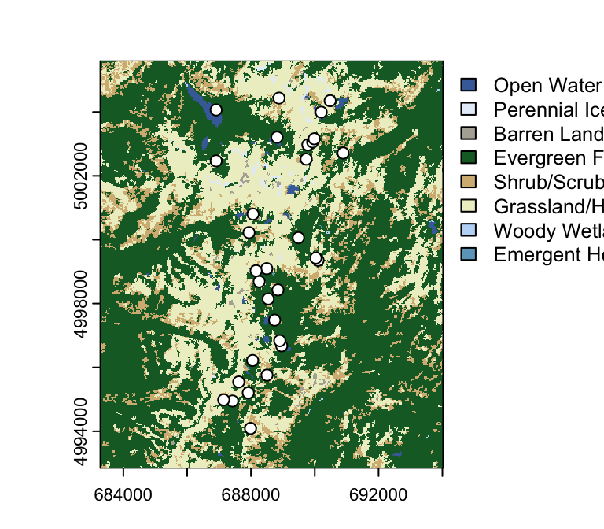

```r
plot(NLCD, col=RAT$color)
points(Sites.sf_c, pch=21, col="black", bg="white", cex=1)
```

### c) Plot the map with `tmap`

```
## Some legend labels were too wide. These labels have been resized to 0.65. Increase legend.width (argument of tm_layout) to make the legend wider and therefore the labels larger.
```

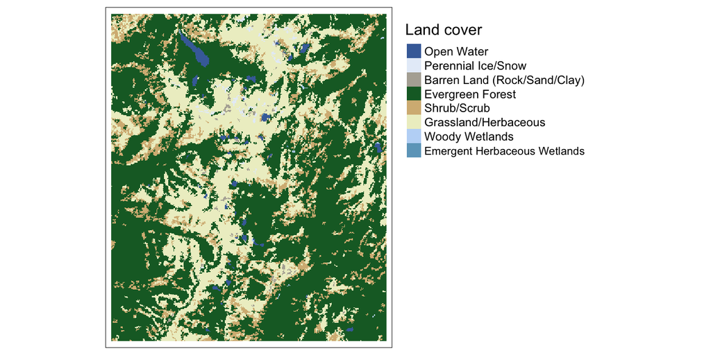

```r
Map3 <- tm_shape(NLCD) +
  tm_raster(style="cat", palette=RAT$color, labels=RAT$nlcd,
            title="Land cover") +
  tm_layout(legend.outside=TRUE, legend.outside.position="right")
Map3
```

Let’s beef it up a bit. We can do so by adding layers to `Map3`:

- To add an additional layer with the sampling sites to the map, we define the data for the layer with `tm_shape`.
- We define how the points should be symbolized with `tm_symbols`.
- We add a North arrow with `tm_compass` , using default settings.
- We add a scale bar with `tm_scale_bar` and set the background to a semitransparent (`bg.alpha=0.5`) light gray (`bg.color="lightgray"`).

```
## Some legend labels were too wide. These labels have been resized to 0.65. Increase legend.width (argument of tm_layout) to make the legend wider and therefore the labels larger.
```

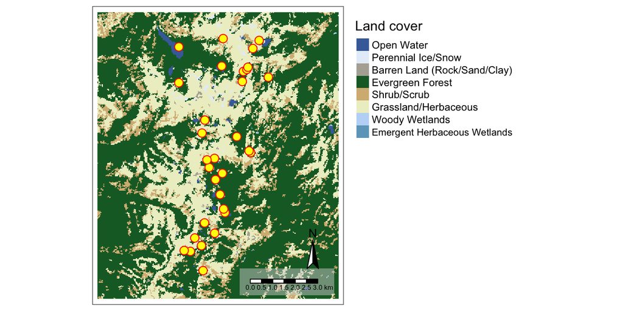

```r
Map4 <- Map3 + tm_shape(Sites.sf_c) +
  tm_symbols(size=0.4, col="yellow", border.col="red") +
  tm_compass() + tm_scale_bar(bg.color="lightgray", bg.alpha=0.5)
Map4
```

This time, we’ll export the map to a PDF file.

```r
#if(!dir.exists(here("output"))) dir.create(here("output"))
#tmap_save(Map4, here::here("output/RasterMap.pdf"), height=6, width=8)
```